# Class Activities

```r
# Load your libraries
library(car)
library(tidyverse)
library(mosaic)
library(pander)
library(ggplot2)
library(readr)
library(stringr)
library(DT)
```

## Questions I have

| Questions | Answers |
| --- | --- |
| What is a residual? |  |

### Week 1 - Simple Linear Regression

#### Wednesday

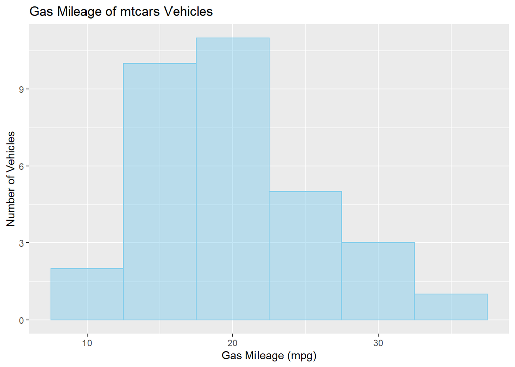

```r
#View(mtcars)
#?mtcars
#mPlot(mtcars)
gf_histogram(~ mpg, data = mtcars, binwidth = 5, fill="skyblue", color = "skyblue") %>%
  gf_labs(title = "Gas Mileage of mtcars Vehicles", y="Number of Vehicles", x="Gas Mileage (mpg)")
```

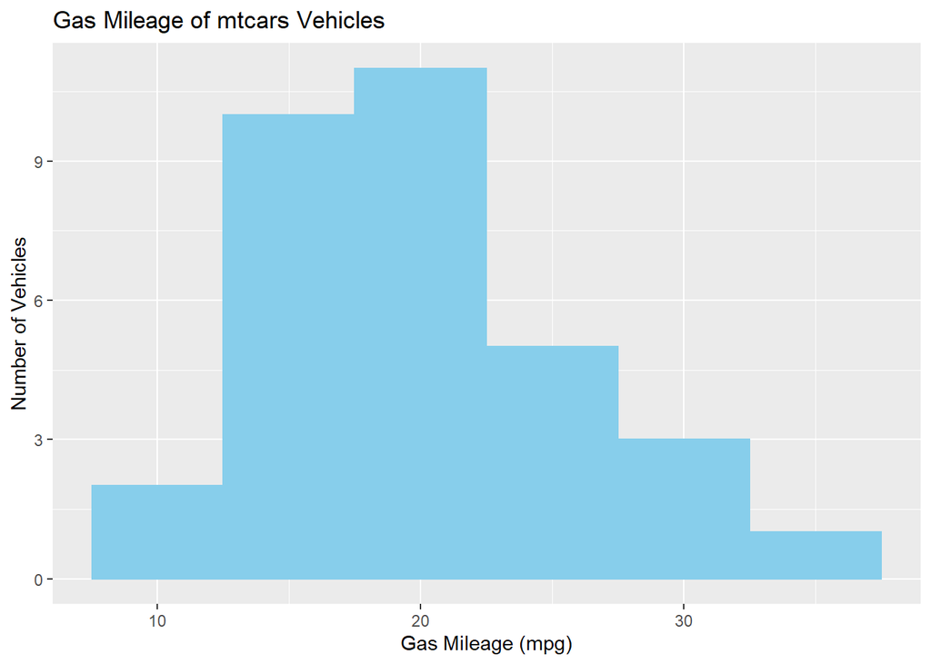

```r
ggplot(mtcars, aes(x=mpg)) +
  geom_histogram(binwidth=5, fill="skyblue", color="skyblue") +
  labs(title="Gas Mileage of mtcars Vehicles", x="Gas Mileage (mpg)", y="Number of Vehicles")
```

```r
mean(mtcars$mpg)
```

```
## [1] 20.09062
```

```r
sd(mtcars$mpg)
```

```
## [1] 6.026948
```

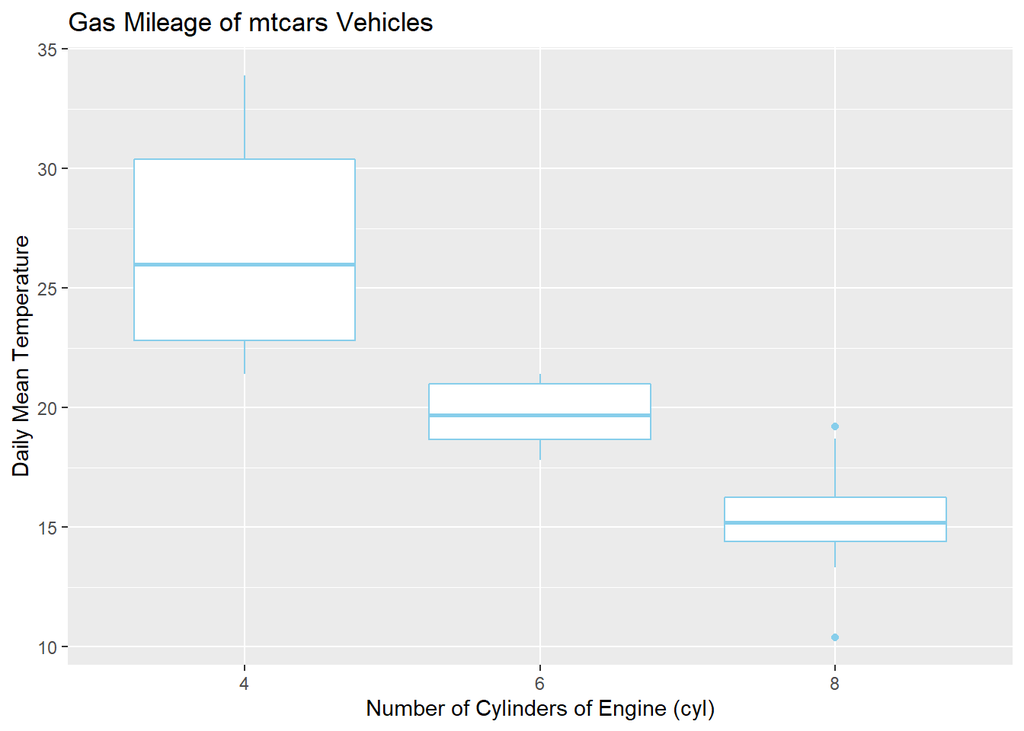

```r
#mtcars2 <- as.factor(mtcars$mpg)
#View(mtcars2)

ggplot(mtcars, aes(x=factor(cyl), y=mpg)) +
  geom_boxplot(color="skyblue") +
  labs(title="Gas Mileage of mtcars Vehicles", x="Number of Cylinders of Engine (cyl)", y="Daily Mean Temperature")
```

```r
mtcars %>%
  group_by(cyl) %>%
  summarise(sdTemp =sd(mpg),
            mean = mean(mpg))
```

```
## # A tibble: 3 x 3
##     cyl sdTemp  mean
##   <dbl>  <dbl> <dbl>
## 1     4   4.51  26.7
## 2     6   1.45  19.7
## 3     8   2.56  15.1
```

```r
mylm <- lm(mpg ~ qsec, data=subset(mtcars, am==0))
summary(mylm)
```

```
##
## Call:
## lm(formula = mpg ~ qsec, data = subset(mtcars, am == 0))
##
## Residuals:
##     Min      1Q  Median      3Q     Max
## -6.4551 -1.2411  0.2417  1.8046  4.6390
##
## Coefficients:
##             Estimate Std. Error t value Pr(>|t|)
## (Intercept)  -9.0099     7.3095  -1.233  0.23449
## qsec          1.4385     0.4002   3.594  0.00224 **
## ---
## Signif. codes:  0 '***' 0.001 '**' 0.01 '*' 0.05 '.' 0.1 ' ' 1
##
## Residual standard error: 2.974 on 17 degrees of freedom
## Multiple R-squared:  0.4318, Adjusted R-squared:  0.3984
## F-statistic: 12.92 on 1 and 17 DF,  p-value: 0.002237
```

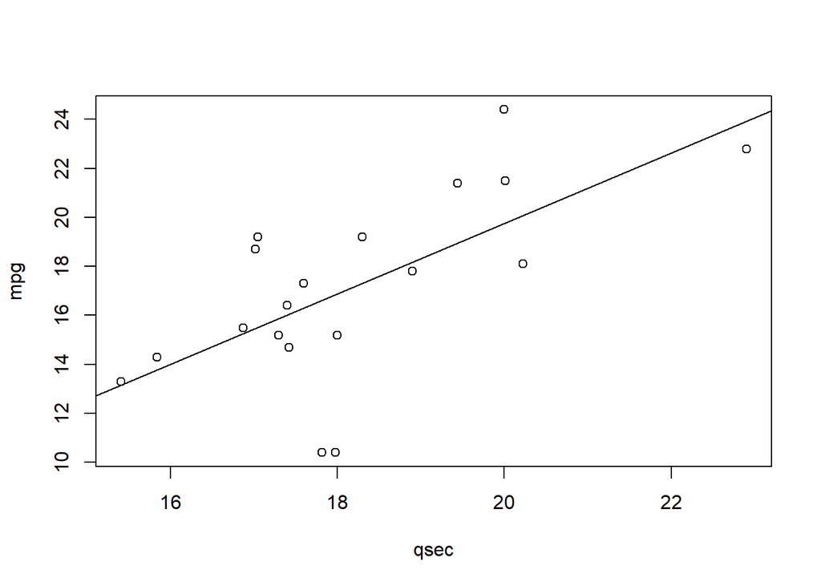

```r
plot(mpg ~ qsec, data=subset(mtcars, am==0))
abline(mylm)
```

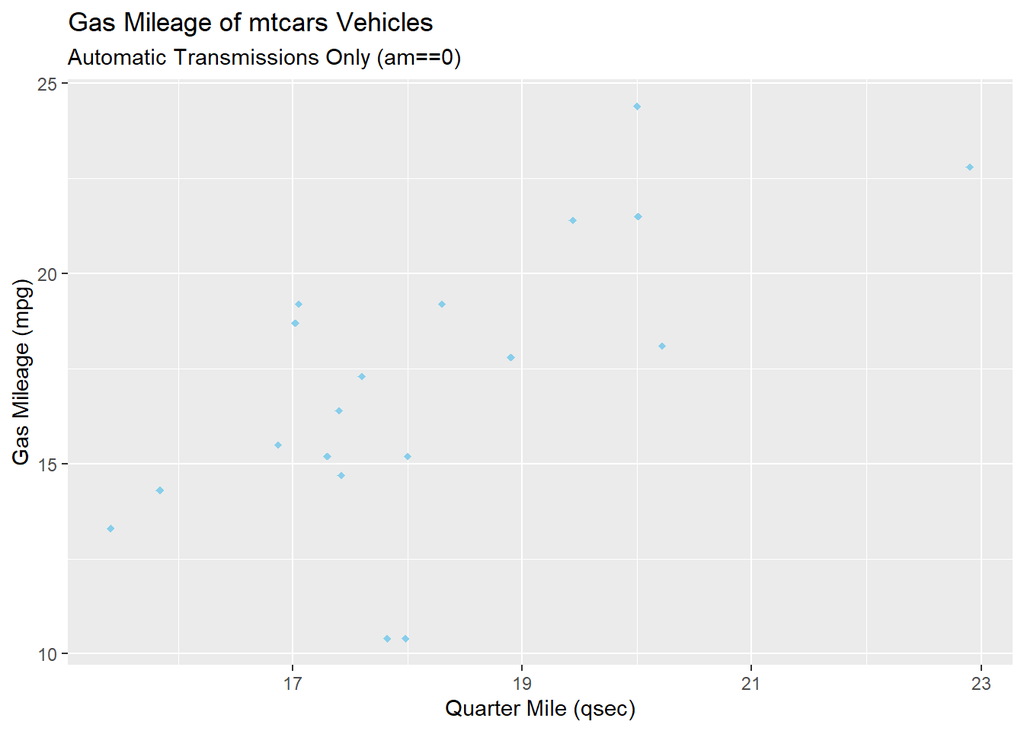

```r
#mPlot(mtcars)
mtcars %>%
  filter(am==0) %>%
  ggplot(aes(x = qsec, y = mpg)) +
  geom_point(color = "skyblue", pch = 18) +
  labs(title = "Gas Mileage of mtcars Vehicles", subtitle = "Automatic Transmissions Only (am==0)", y= "Gas Mileage (mpg)", x = "Quarter Mile (qsec)")
```

```r
-9.0099 + 1.4385*19
```

```
## [1] 18.3216
```

#### Friday

```r
#?Utilities
#View(Utilities)

# Perform the Test
mylm <- lm(elecbill ~ kwh, data = Utilities)
summary(mylm)
```

```
##
## Call:
## lm(formula = elecbill ~ kwh, data = Utilities)
##
## Residuals:
##      Min       1Q   Median       3Q      Max
## -30.3032  -9.2989   0.2645   7.6568  26.7653
##
## Coefficients:
##              Estimate Std. Error t value Pr(>|t|)
## (Intercept) -5.000714   4.521874  -1.106    0.271
## kwh          0.108754   0.005816  18.698   <2e-16 ***
## ---
## Signif. codes:  0 '***' 0.001 '**' 0.01 '*' 0.05 '.' 0.1 ' ' 1
##
## Residual standard error: 12.66 on 115 degrees of freedom
## Multiple R-squared:  0.7525, Adjusted R-squared:  0.7503
## F-statistic: 349.6 on 1 and 115 DF,  p-value: < 2.2e-16
```

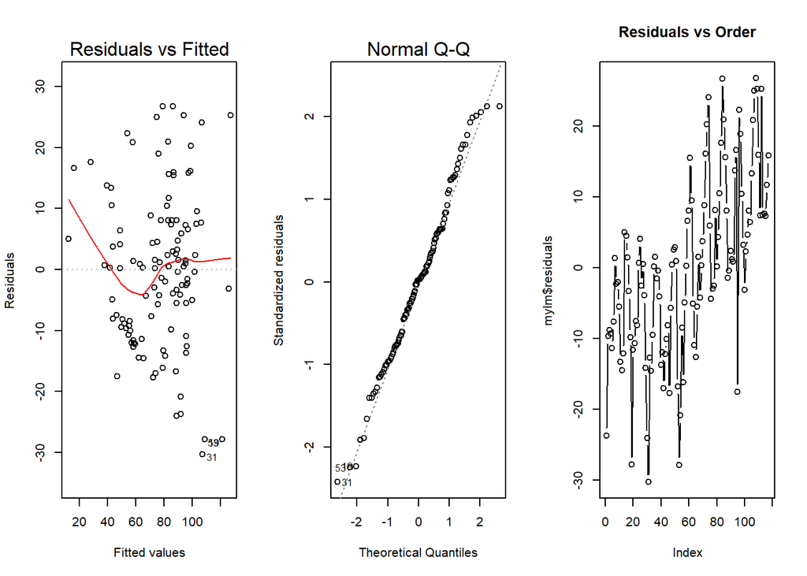

```r
# Check Assumptions
par(mfrow=c(1,3))
plot(mylm, which=1:2)
plot(mylm$residuals, type = "b", main = "Residuals vs Order")
```

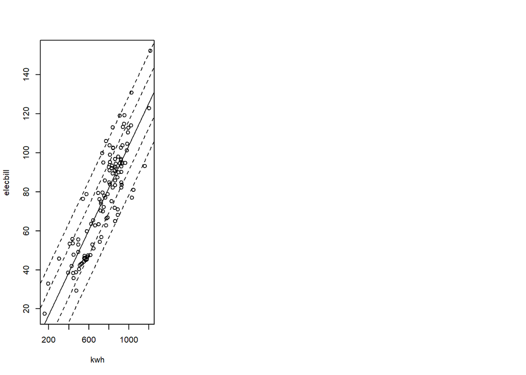

```r
#plot(mylm, which = 1)
# qqPlot(mylm$residuals, main = "Q-Q Plot of Residuals", id = FALSE)

#Plot the Regression Line
plot(elecbill ~ kwh, data = Utilities)
abline(mylm)
abline(-5.000714+12.66, 0.108754, lty=2)
abline(-5.000714-12.66, 0.108754, lty=2)
abline(-5.000714+2*12.66, 0.108754, lty=2)
abline(-5.000714-2*12.66, 0.108754, lty=2)
```

Being more extreme Test statistic and The line is the average y-value. The slope is the change in the average y-value. The y-intercept is the average y value when x equals zero.

Never touches x-axis. 68, 95, 99.7

$$\underbrace{Y_i}_\text{Some Label} = \overbrace{\beta_0}^\text{y-int} + \overbrace{\beta_1}^\text{slope} \underbrace{X_i}_\text{Some Label} + \epsilon_i \quad \text{where} \ \epsilon_i \sim N(0, \sigma^2)$$

### Week 2

#### Monday

$\underbrace{Y_i}_\text{High Temp} = \beta_0 + \beta_1 X_i + \epsilon_i \quad \text{where} \ \epsilon_i \sim N(0, \sigma^2)$

$\hat{Y}_i = b_0 + b_1 X_i$

Box said “All models are wrong. Some are useful.”

What is a residual?  
* Residuals are the distance from the line to the data point. How far the dot has deviated from the line.

In which direction (vertical, horizontal, diagonal) is a residual? Why?  
* It’s vertical because it cooresponds to the x-value.

What happens to the magnitude of the residuals as you move the line to the “center” of the data? Or away from the data?  
* The residuals become the smallest they can be when the line is centered.

What are positive or negative residuals?  
* That a data point is above or below the line.

What happens when we add or sum the residuals together? * We get zero.

What do the shaded “squares” that appeared next to each residual bar in the scatterplot represent?  
* They represent the squared residual or the “area”.

What does the length of the shaded bar under “Squared Residuals”, my estimation for the line, represent?  
* How far off my predicted line is from zero.

Why would the phrase “Least Squares Regression Line” be a good name for the “Best-Fit Line”?  
* The “Best-Fit Line” creates residuals that are the smallest they can be.

What does the length of the shaded bar under “Squared Residuals”, the best fit line, show?  
* The mathmatically correct way to get the least residuals.

How is the “Sum of Squared Residuals” and “Correlation Coefficient” effected by the distance of the dots from the line? * As the dots are further from the line, the residuals are greater. As the dots are further from the line, the correlation becomes smaller.

What happens to the “Sum of Squared Residuals” and “Correlation Coefficient” if you put all of the dots exactly on the line?  
* You would get a correlation of 1 and a sum of squared residuals of 0.

#### Wednesday

#### Friday

### Week 3

#### Monday

#### Wednesday

#### Friday

### Week 4

#### Monday

#### Wednesday

#### Friday

### Week 5

#### Monday

#### Wednesday

#### Friday

### Week 6

#### Monday

#### Wednesday

#### Friday

### Week 7

#### Monday

#### Wednesday

#### Friday

### Week 8

#### Monday

#### Wednesday

#### Friday

### Week 9

#### Monday

#### Wednesday

#### Friday

### Week 10

#### Monday

#### Wednesday

#### Friday

### Week 11

#### Monday

#### Wednesday

#### Friday

### Week 12

#### Monday

#### Wednesday

#### Friday

### Week 13

#### Monday

#### Wednesday

#### Friday

### Week 14

#### Monday

#### Wednesday

#### Friday